# Welcome to Python!

This crash course aims to get you started in Python 3. We'll cover jupyter notebooks, git repostories, python packages and a bunch of other tricks I've found useful for data analysis with Python. My goal is to motivate you to want to use python for your next analysis task, by making it accessible to you and by giving you the tools to get started. This tutorial won't bore you with a heap of basic syntax changes; these are somthing you can figure out as you go. Rather, I'll make sure you have an installation of python that works, give you some tools to handle STM data, and show you a few tricks that I've learned which make Jupyter notebooks a good environment for data analysis. Mostly, we'll do this by walking through three analysis projects and hopefully we'll pick up some syntax as we go.

A resource that I find really helpful for learning python are the [video tutorials](https://training.enthought.com) offered by enthought canopy. They are free for anyone with an .edu email address! Some other useful resources for learning the Python language and syntax are [Learn Python the Hard Way](http://learnpythonthehardway.org/book/) and [Code Academy](https://www.codecademy.com/learn/python).

## Outline

- Installing python.
- Jupyter notenooks and IPython.
- **First project:** Plot data from an NVI file.
- Set up GitHub for code sharing.
- Install `stmpy` package.
- **Second project:** Remove piezo drift from SXM topography.
- Tips for jupyter notebooks
- **Final project:** (time permitting) Plot a linecut through a FT-DOS map to visualize QPI.

## What is Python?

Python is an object-oriented programming language, which runs a prompt similar to MATLAB. Unlike lower-level languages, programs written in python do not need to be compiled to run. There are some syntax changes that make python cleaner than other languages, but can catch-out first time users. Most importantly: white space matters!

In Python you tell the interpreter what lines of code are related by their indent level. For example a `for` loop in python is written as:

```
for ix in range(10):
    print('Hello World!')
```

Notice that there is no need to tell the interpreter to end the `for` loop: it will only loop lines of code that are sequential and indented equally.

### Python 2.7x or Python 3.x?

In 2008 python released version 3.0, which is the first version to not be backwards compatible. As a result, two versions of python now exist: 2.7 (last release 2010) and 3.x (released 3.5 in 2015). A lot of packages have not yet been re-written to work with 3.x, so the bulk of python users still run 2.7 (though the tides are shifting). Fortunately, most of the 'standard' scientific packages have be written to work in 3.5, and for our purposes 3.5 is the better choice. The advice from python HQ is that 3.x is the future of the language while 2.7x is legacy.

All that being said, for practical purposes the differences between 2.7x and 3.x is really small! So don't panic if you've started with 2.7x and are worried about switching to 3.5x: you won't have to learn a whole new language, and should just be able to tweak you code a bit. For example, the biggest changes that users report is changing print from a statement to a command:

In Python 2.7x print is a statement, so you can write:

```
print 'Hello World!'
```

But in Python 3.x we need parenthesis so that we call the print function:

```
print('Hello World!')
```

Other changes in Python 3.x that I've encountered include:

- Strings are unicode by default.
- You can use extended unpacking on tuples: `a,*b = (1,2,3)`
- The `range()` command returns an iterable, not a list.
- some other minor changes.

## Installing Python on your machine

### The Anaconda distribution

For beginning users, I strongly recommend the **Anaconda** distribution of python. A distribution contains the python language as well as commonly used packages and an integrated development enviroment (IDE) so that you can get started writing scripts straight away. Anaconda also takes care of keeping python up-to-date, and has jupyter notebooks built in.

For Windows or Mac, I've put the install files for Python 3.5 on the `FAS` server, just copy the files to your machine and run. The prompts should guide you through the installation. A copy of these notes are also located in the same folder:

> `/hoffmanlab/Software/_Python/`

For those who can't access the `FAS` server, you can download Anaconda from https://www.continuum.io/downloads. Make sure you install Python 3.5. Once installed you should be able to launch a Jupyter notebook from within Anaconda.

The installation is around 1.8GB in total, so for those who prefer a slimmer installation...

### Manual installation

On OSX (I'm assuming there is a similar method for Windows) python can be easily installed and maintained with [homebrew](http://brew.sh) or from the [source code](https://www.python.org) (slightly more tricky). With homebrew you can install python using the terminal command:

> `brew install python3`

Once python is installed the acompanying package manager `pip3` can complete the distribution. In particular you should run:

> `pip3 install --upgrade pip`

> `pip3 install jupyter scipy matplotlib`

Once installed you should be able to launch a jupyter notebook from the terminal:

> `jupyter notebook`

## Jupyter and IPython

Okay; *Jupyter, IPython, python, scipy, ...*: **what's going on?!**

Don't panic! Python is a pretty bare language by itself: most of it's power in data analysis comes from 3rd-party, open-source packages. These are just other people's python code which you can use. To explain what we've encountered so far:

- **Jupyter** is the notebook view that we're currently using. It's similar to a mathematica notebook and comprises of cells that can be `code`, markdown (a html-ish typesetting language) or a variety of headings. For data analysis Jupyer notebooks are great as keeping track of what you're doing and provide a place to write comments about data or things you uncover during analysis. However a jupyter notebook, is just a client; it doesn't have to run python code, but could do R or another language altogether. In fact, every Jupyter notebook runs on a kernel, which you can see in Anaconda.
- **IPython** is the kernal that we use to run python in jupyter! It stands for *Interactive*-Python and is an extention of the python language that provides:
  - in-line plots: in python you usually have to call a `show()` method everytime you want to see a plot. IPython shows outputs just below the cell.
  - tab auto-completion: this helps to fill in long vairable names or see available attributes for an object: just try

    ```
    myList = [1,2,3]
    ```

    `myList.`"tab" to see a list of available operations on `myList`.
  - magic commands: these are useful functions that are prefaced by the `%` symbol. Some examples are:

    `%pylab inline` - populates local namespace with numpy and pylab variables `%cd /Users/Harry/Desktop` - change current directory to my desktop. `%store myList` - save a variable from the namespace to be accessed by other ipython kernals.

Here is a graphic that explains the relationship between python, ipython and jupyter:

[figure not shown]

## Getting started in Python

### Importing packages

In python, code is organized into libraries, which comprise of modules that are loaded into a current session using the `import` command. One of the most useful packages for data crunching is `numpy`,, which gives you access to $n$-dimensional arrays and a bunch of numeric functions like `sin` and `exp`. For scientific computing, especially optimization, the `scipy` package contains some useful functions. Along with the plotting library `matplotlib`, this constitues the bulk of the [scientific stack](https://www.scipy.org/stackspec.html). In python, we can load these packages into the current session using:

```
import numpy as np
import scipy
import matplotlib as mpl
import pylab as plt
```

You can also import a specific part of a package using the `from ... import ...` syntax to save time importing the whole thing. This is usually done for parts of `scipy`. Here I'm loading a general non-linear optimization algorithm, which I can then call directly.

```
from scipy.optimize import minimize
```

Now that we have these packages imported, we can access their functions by writing the package name (or our chosen name) followed by a dot. So to create and plot a numpy array we would write:

```
myArray = np.array([1,2,3])
plt.plot(myArray)
plt.show()
```

For commonly used packages such as numpy and matplotlib, it can get tedious to keep having to preface the package name everytime we want to use it. Fortunately, we can import the contents of any package to the local namespace using the command:

```
from numpy import *
myArray = array([1,2,3])
```

In **IPython** (and jupyter notebooks) we can use a *magic* command to load the commonly used parts of matplotlib and numpy to the namespace. Most of my notebooks start with this command:

```python
%pylab inline
```

### First project: plotting an NVI file

As an example for this tutorial we are going to import an NVI (NISTview image) file to our ipython notebook and plot the data. I've placed the NVI file and script that Annie has written to import it on the `FAS` server. First copy the tutorial direclory containting the files to your local machine.

> `/hoffmanlab/Software/_Python/Tutorial`

In IPython we can switch directories easily using the magic command `%cd`. Let's navigate to that directory now:

```python
%cd ~/Desktop/Tutorial
```

```
/Users/Harry/Desktop/Tutorial
```

If you frequently need to switch to a directory with a long name, you can set up a bookmark in IPython using the magic command `%bookmark <name>`, from within the directory. Then you can use `%cd <name>` to jump to that directory from anywhere.

Let's start by importing the `read_nvi.py` file into our session. **Note:** you don't need to add the `.py` when importing packages.

```python
import read_nvi
```

The `read_nvi.py` script has a function called `load_nvi` which we can access with `read_nvi.load_nvi(filePath)`. It will open the NVI file specified by `filePath` and return an object that contains the header information and data within the file. Let's load the file into a variable called `FeSe`:

```python
FeSe = read_nvi.load_nvi('FeSe_image.NVI')
```

Great! We've loaded the contents of the file and have them available to us as attributes of the variable `FeSe`. To see all of the attributes that any object has we can use tab auto-completion in IPython. Just do `FeSe.`"tab" and you should see a list pop up:

- `FeSe.data`
- `FeSe.header`
- `FeSe.info`
- `FeSe.raw`

The `FeSe.info` variable contains a bunch of useful experimental parameters that can tell us about the data. `FeSe.header` is similar, but contains much more information. `FeSe.raw` contains the complete contents of the file, but the variable we are interested in is `FeSe.data`. Let's try and plot that as a colormap now. Because we have `pylab` loaded into the session, this is accomplished by just one command:

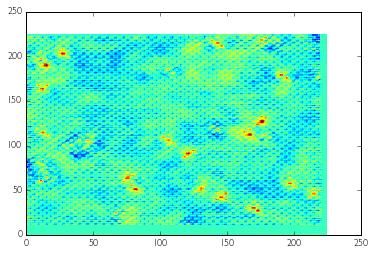

```python
pcolormesh(FeSe.data)
```

Usually we want to adjust various plotting parameters before saving a figure for a presentation. A good reference for this are the examples on http://matplotlib.org. Here I'll show you some basic operations to make this figure more presentable.

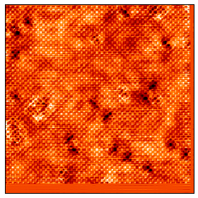

```python
figure(figsize=[4,4])    # We want a square figure
gca().set_xticks([])    # Turn off the x and y ticks
gca().set_yticks([])
pcolormesh(FeSe.data, cmap=cm.gist_heat_r)    # Use a Blue colormap: Use cm."tab" to see all the other options!
clim(-0.04,0.07)    # Adjust the color axis
tight_layout()    # Make sure the figure fits within the window you will save
savefig('IMG_FeSeData.png', dpi=300)   # Use a custom dpi of at least 200 when saving for good quality figures
```

Congratulations! You've made your first plot using python! If you had wanted to save this in another format, such as vector graphics, you just need to change the desired extention. Try:

```
savefig('IMG_FeSeData.eps')
```

**Note:** vector graphics can become quite large for colormesh files.

## Working collaboratively with GitHub

For STM data analysis, it's important to be able to easily share code and results so that other can follow your analysis steps. For large projects it becomes difficult for everyone to keep an up-to-date version of the same code, without sending multiple copies by email. One solution to this is to use GitHub to sync everyones changes to a cloud-based drive (called a repository).

GitHub makes it easy to update code and to push those update to other users. We start by making a project, which has a master branch hosted on www.github.com. Collaborators can `clone` the master branch onto their local machine, and make their own edits. You can `commit` any changes and then `push` them back to the master branch to make then part of the project. Alternatively, GitHub allows many branches to be maintained in parallel.

To get started sign up for a free account on [GitHub](https://github.com) then follow the prompts to download the[desktop install files. This gives you the option to install a [GUI](https://desktop.github.com) to manage repositories or to directly manage things from command line tools.

**Note:** You need to verify email address after creating an account.

To help you get familiar with GitHub, there is a 10-munite introductory [tutorial](https://guides.github.com/activities/hello-world/) that cover the workflow in GitHub. If you want to use `git` from the command line the commonly used commands are:

```
git clone <url>    # Creates repository
git add *    # Add all changes to be committed
git commit -m "commit message"    # Commit changes (requires a message)
git push origin master    # Push changes to the master branch
git pull    # Sync your local repository with github.com
```

## Stmpy: STM-python data analysis package

I've collected some STM analysis code into a python package called `stmpy`, which is available on GitHub [here](https://github.com/harrispirie/stmpy). If you are using GitHub Desktop, open this in the app and clone the respostory somewhere on your local machine. This way you can easily maintain an up-to-date version of the code and make your own contributions to the main branch.

To accomplish the same thing using the command line (on OSX), first navigate to where you would like the package to be installed then run:

> `git clone https://github.com/harrispirie/stmpy`

This repository is set up to be a python **package**, which contains a few extra bits from a bare script that allow it to be installed on your machine and called from anywhere. Specifically, a package must contain a `setup.py` file that tells python how to install it, and a `__init__.py` file within every subdirectory. Adding `__init__.py` to any directory will tell python that that directory is a *module* or *sub-module* that contains other `.py` scripts.

From the first `stmpy` directory, you can install the package from the command line by typeing:

> `python3 setup.py develop`

Adding the `develop` keyword means that any changes you make to the contents of `stmpy` will immediately be available when you `import` it.

### Second project: correcting for piezo drift

Now that you have installed the stmpy package, you should be able to `import` it into any python session, without having to work in the directory that contains the source code. Let's try that now:

```python
import stmpy
```

To see the contents of any package you can use the tab auto completion. Here from the list `stmpy.`"tab", the most useful functions are:

- `stmpy.load`: loads Nanonis(`.3ds`, `.sxm` and `.dat`) and NISTView (`.nvi` and `nvl`) data types.
- `stmpy.tools`: has some basic analysis tools including: azimutal averaging, linecuts, remove background polynomial and symmetrize QPI maps.

Let's demonstrate some of the functionality now by opening a topography file straight from nanonis:

```python
FeSe2 = stmpy.load('FeSe_topography.sxm')
```

The load function returns a python object, which has the data stored as one of its attributes (remember: you can use tab auto-completion to see a list of attributes for any object). In this case the `.sxm` file has 8 channels of data recorded, with a forward and backward scan direction for each of: topography, current, LIY 1, LIY n. Information about the scan conditions are stored under `FeSe2.header`.

Let's take a look at the topography channel, which can be accessed by `FeSe2.channels['Z_Fwd']` or by using the shourtcut `FeSe2.Z`.

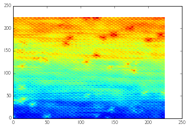

```python
pcolormesh(FeSe2.Z)
```

It's clear that there was a significant drift in the `Z` height as the scan was taken. We can correct for this by removing a linear term from each line in the image using the `removePolynomial1d` function in the `tools` module. To see the syntax for any function you can print its `__doc__` string:

```python
print(stmpy.tools.removePolynomial1d.__doc__)
```

```
 Removes a background polynomial of degree n to the line y(x) in the range fitRange (optional).
        Usage: yCorrected = removePolynomial1d(y, n)
```

This function is written for one-dimensional data only, so to correct a 2D image, we need to call it on every row in our image. Let's start by pre-allocating space: we know that the corrected image will have the same dimensions as the original image, so we can create an array of the same (2D) shape using the `zeros_like` command (part of the `numpy` package).

```python
FeSe2_bkSubtract = zeros_like(FeSe2.Z)
```

Now we want to iterate over every row in our image and fill in the corresponding row in the `Fese2_bkSubtract` variable. We can do this using a `for` loop. Here's our first real glipse of python syntax, which I want to explain to you by comparing with a `for` loop in MATLAB.

As a simple example, let's suppose that we want to print out every element in an array:

```
myArray = array([5,3,2])
```

In MATLAB, you could acomplish this with the following `for` loop:

```
for ix = 1:numel(myArray)
    disp(myArray(ix))
end
```

Here we loop over an index and use that index to lookup the corresponding value. In python we do this more directly my looping over the elements of the array:

```
for value in myArray:
    print(value)
```

There are a couple of other syntax changes here too: the ':' tells python to expect an indented block of code and we don't need to end the `for` loop because we have used indentation.

Sometimes it's useful to know the iteration number in python as we loop. We can return both the array value and the iteration value using the `enumerate()` command:

```
for ix, value in enmuerate(myArray):
    print(value)
    print(myArray[ix])
```

Both `print` statements here have the same output. Also note that in python we use square brakets to index an array, and that indexing starts from zero.

In our example we want to loop over every row in the 2D matrix `FeSe2.Z` and write our result to the corresponding row in `FeSe_bkSubtract`, so this is one of the times where it can be useful to use `enumerate()` to return an index and a value for every iteration. The syntax looks like this:

```python
for ix, row in enumerate(FeSe2.Z):
    FeSe2_bkSubtract[ix] = stmpy.tools.removePolynomial1d(row, 1)
```

Now lets take a look at the result, and save it to file.

[figure not shown]

```python
figure(figsize=[4,4])
gca().set_xticks([])
gca().set_yticks([])
pcolormesh(FeSe2_bkSubtract, cmap=cm.Blues_r)
clim(-3e-11, 9e-11)
tight_layout()
savefig('IMG_FeSeTopography.png', dpi=300)
```

## Workflow in jupyter notebooks

Jupyter notebooks offer a clean place to record your analysis as it progresses. The notebook is comprosed of cells, which can be excecuted as code or converted to markdown by pressing `Esc` then `m`, or by selecting markdown from the drop down menu. Markdown is a typesetting language that allows you to input math in latex form and format text using simple commands. A helpful reference for markdown syntax can be found [here](https://github.com/adam-p/markdown-here/wiki/Markdown-Cheatsheet), or alternatively, double-click any cell in this notebook to see its markdown input.

### Jupyter notebook tricks

I want to demonstrate some of the tricks I've learned whilst analyzing data in jupyter notebooks that have made things miuch easier.

#### 1. Save a variable to be accessed in other ipython sessions

IPython has a neat trick that lets you save variables to use in other IPython sessions (usually the namespace is cleared when you close the IPython kernel). You can do this using the magic command:

```
%store varaibleName
```

To load all stored variables use:

```
%store -r
```

Check the [documentation](http://ipython.org/ipython-doc/rel-0.12/config/extensions/storemagic.html) for more information about using this.

**Note:** This only works for variables, not for objects or attributes of an object. For example the following code generates an error:

```
%store FeSe2.Z
```

You can get round this easily by making a new variable and storing that:

```
FeSe2_Z = FeSe2.Z
%store FeSe2_Z
```

#### 2. Using multiple cursors to edit code

Recently I found a really useful trick completely by accident, but I use it all the time now so I though I'd share. If you hold down `command` (presumably `ctrl` on windows) then click somewhere in a cell, you will generate another cursor at that point. There is no limit to the number of cursors you can have at once! I find this really useful for changing variable names or by simultaneously changing a bunch of values at the same time.

#### 3. Using style sheets for consistent plotting

To avoid always adding the same formatting specifications to plot commands, you can create a style sheet that contains your settings and load it once for the whole session. Instructions on creating a style sheet can be found [here](http://matplotlib.org/users/style_sheets.html), alternatively you can use the one I have made for you. It's located in the `Tutorial` folder on the `FAS` server:

> `/hoffmanlab/Software/_Python/Tutorial/Thin.mplstyle`

We need to copy this into the directory that maplotlib uses to store plotting preferences. This differs depending on the machine you are using, but you can find yours with:

```python
matplotlib.get_configdir()
```

```
'/Users/Harry/.matplotlib'
```

Move the file `Thin.mplstyle` into the `stylelib` subdirectory (create it if it doesn't exist). Now we can load it into our ipython session. We need to restart the kernel to reload `matplotlib`, which you can do by pressing `Esc` then double-pressing `0` (zero). The stlye sheets are loaded with the command:

```python
# You need to re-import packages after restarting the kernel
%pylab inline
%cd ~/Desktop/Tutorial
import stmpy
pylab.style.use('Thin')
```

```
/Users/Harry/Desktop/Tutorial
```

Let's use `stmpy.load` to open the DOS map `SmB6_DOSmap.3ds` and take a look at the result:

```python
SmB6 = stmpy.load('SmB6_DOSmap.3ds')
```

```
File import successful.
Corrected for a bias offset of -0.67 meV
```

This returns an object with the data as attributes. For a DOSmap it automatically compensates for bias offset, by finding the where the current crosses zero. In this data set it has shifted all energies by -0.67meV. The 3ds object also includes the average dI/dV as an attribute called `SmB6.didv`. Let's see what it looks like with this style sheet:

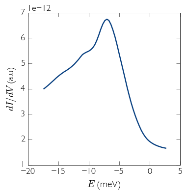

```python
plot(SmB6.en, SmB6.didv)
# It's easy to use LaTeX math in figure labels:
xlabel('$E$ (meV)')
ylabel('$dI/dV$ (a.u)')
```

## Final project: Taking a linecut in QPI data

This is a slightly longer project that hopefully will give you some more exposure and experience using the python syntax. The data set we've just loaded contains the signal of a Dirac-like surface state that we would like to tease out of the data. I've broken down the approach to visualize this signal into two steps:

- Compute the fourier transform of each layer in the DOS map
- Take a linecut between the bragg peaks in the 3D data set

This a little bit harder than our previous project because the data we are working with is 3D, but we can still use the same approach with a `for` loop. First, we're going to start by pre-allocating an array to store the Fourier transform. We know that this will be the same shape as the `LIY` data, so we can use `zeros_like` again:

```python
SmB6_FT = zeros_like(SmB6.LIY)
```

Now lets compute the Fourier transform for each energy layer separately and assign the result to the correct space in `SmB6_FT`. To understand more about what's going on here let's look at the `shape` of the data set:

```python
SmB6.LIY.shape
```

```
(61, 128, 128)
```

When we index into this data set, the first index corresponds to energy (there are 61 energy layers - you can check by running `len(SmB6.en)`), whereas the second and third indicies correposng to the $x$ and $y$ directions. So if we want to access just the first energy layer we use:

```
SmB6.LIY[0,:,:]
```

Here the '`:`' means 'everything', just like in MATLAB. In fact, in python this it is optional to include this, and it is usally implied. We can write:

```
SmB6.LIY[0]
```

Which gives the same results. If we write a `for` loop to iterate over `SmB6.LIY`, it will use the first index (energy), specifically, for the `i`th iteration it will return `SmB6.LIY[i]`. This is just the `i`th energy layer, which is exactly what we want to take the Fourier transform of.

We compute the Fourier transform in 3 steps: first take the 2D FFT using `fft.fft2()` (part of the `numpy` package); then shift the origin of the 2D FFT from being in the lower left corner to being in the center using `fft.fftshift`; finally, take the `absolute` value of the FFT to return a real number.

```python
for ix, layer in enumerate(SmB6.LIY):
    FT = fft.fft2(layer)
    FT_shift = fft.fftshift(FT)
    SmB6_FT[ix] = absolute(FT_shift)
```

Let's take a look at the result for the first energy layer:

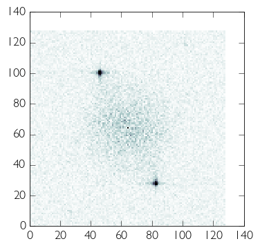

```python
pcolormesh(SmB6_FT[0])
clim(0,3e-10)
```

Great! The dark spots at `(46,100)` and `(82,28)` are the Bragg peaks corresponding to a $(2\times 1)$ surface reconstruction. The signal is strongest in that direction, so we want to take a linecut between the Bragg peaks. There is a tool in the `stmpy.tools` package that will compute a linecut for a 2D image, but we will need to modify it to work for our 3D slice.

Let's take a look at the `__doc__` string for the function to see what parameters we need to pass to it:

```python
print(stmpy.tools.linecut.__doc__)
```

```
 Use linear interpolation on a 2D data set F, sample along a line from (x1,y1) to (x2,y2) in n points

Usage:  x_linecut, y_linecut = linecut(image, x1, y1, x2, y2, n)
```

To get a sense for how this function works, let's start by computing the linecut for the first energy layer. I'm using 150 points for to compute the linecut.

```
(0, 3e-10)
```

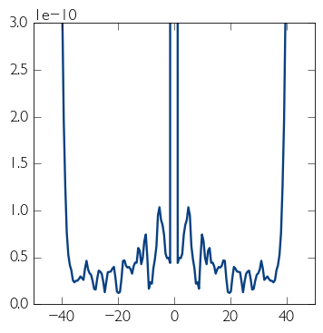

```python
x_linecut, y_linecut = stmpy.tools.linecut(SmB6_FT[0], 46, 100, 82, 28, 150)
plot(x_linecut, y_linecut)
ylim(0,3e-10)
```

So we have high intensity around the Bragg peaks (at $\pm$`40`) and a huge peak at `0`. Our goal is to get one of these lines for each energy and to store them together in an array. This time, when we pre-allocate array space we cannot use `zeros_like` because nothing has the same dimensions as our result. We can manually specify the size of the array using `zeros()`. In this case we want it to be: $$ (\text{number of energy layers} \times \text{number of points in linecut}) = (61 \times 150)$$

```python
SmB6_linecut = zeros([61, 150])
```

Now we're going to do a process that should be becoming familiar: loop though each energy layer and compute the linecut.

```python
for ix, layer in enumerate(SmB6_FT):
    r, SmB6_linecut[ix] = stmpy.tools.linecut(layer, 46, 100, 82, 28, 150)
```

We can visualize the result by plotting the matrix as a colormap with the command `pcolormesh()`. This time we will add optional arguments to specify the $x$ and $y$ axis. We can use the `r` variable from the linecuts to give us the number of pixels away from the origin as our $x$ axis and use the energy attribute of our data set `SmB6.en` as the $y$ axis.

Then we can tidy up the plot and save it.

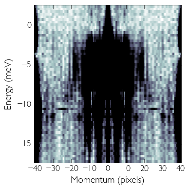

```python
pcolormesh(r, SmB6.en, SmB6_linecut, cmap=cm.bone_r)
clim(5e-12, 8e-11)
axis('tight')
xlabel('Momentum (pixels)')
ylabel('Energy (meV)')
tight_layout()
savefig('IMG_DiracStates.png', dpi=300)
```

The signal is pretty weak! But you can just about make out the X-like Dirac state!